# Konjunkturrapport

[figure not shown]

Uppdaterad 2026-10-29  
Regional utveckling, Region Kronoberg  
Rapporten är framtagen inom enheten Verksamhetsstöd, Regional utveckling,  
Region Kronoberg. Syftet är att med hjälp av indikatorer ge en övergripande bild av konjunkturläget och näringslivets status i Kronobergs län. Rapporten uppdateras kvartalsvis i takt med att ny statistik publiceras.

Kontakta oss! Frågor kring rapportens innehåll ställs till regutveckling.analys@kronoberg.se.

# Kort sammanfattning

Svensk ekonomi befinner sig fortfarande i lågkonjunktur, men återhämtningen har stärkts under 2026. BNP ökade tydligt under andra kvartalet och stämningsläget i näringslivet är starkare än normalt. Hushållens konfidensindikator föll dock i oktober, framför allt på grund av mer negativa förväntningar på det egna ekonomin och Sveriges ekonomi framöver. Hushållens konsumtion och den offentliga sektorns efterfrågan bidrar till återhämtningen. Svensk export har utvecklats starkt under året, trots en osäker omvärld med höga energipriser och geopolitiska spänningar. Konjunkturinstitutet bedömer att lågkonjunkturen ebbar ut under 2027.

Även i Kronoberg finns tecken på en förbättring. Arbetslösheten har minskat jämfört med föregående år och ligger nu ungefär i nivå med riket. Långtidsarbetslösheten har också minskat under de senaste månaderna, men utgör fortfarande en betydande utmaning eftersom omkring två tredjedelar av de arbetslösa har varit utan arbete i mer än sex månader. Varslen ligger på en förhållandevis låg nivå sett ur ett historiskt perspektiv, även om enskilda större varsel har förekommit. Samtidigt är efterfrågan på arbetskraft fortsatt dämpad, med färre lediga jobb än för ett år sedan. Arbetsmarknaden följer ofta konjunkturutvecklingen med viss fördröjning, eftersom företagen vanligtvis avvaktar tills efterfrågan stärkts mer varaktigt innan de ökar sin bemanning.

Företagandet visar positiva signaler, med betydligt fler nystartade företag under januari–september än under motsvarande period 2025. Sammantaget pekar utvecklingen i en mer positiv riktning, men den ekonomiska återhämtningen har ännu inte fått fullt genomslag på Kronobergs arbetsmarknad. Inför 2027 blir det särskilt viktigt att följa om den stärkta konjunkturen leder till ökad efterfrågan på arbetskraft och en fortsatt minskning av arbetslösheten.

# Konjunktur

Sverige befinner sig i en lågkonjunktur, samtidigt är återhämtningen i full gång och lågkonjunkturen håller på att ebba ut. BNP ökade tydligt under det andra kvartalet. Konjunkturinstitutet bedömer att lågkonjunkturen ebbar ut under 2027. Under nästa år ökar hushållens köpkraft mer försiktigt som en följd av stigande inflation och räntor. Konsumtionen har ökat kvartal för kvartal under de senaste åren och utgör en viktig drivkraft för återhämtningen. Under året stärks hushållens köpkraft med stöd av stigande reallöner och skattelättnader. Även den offentliga konsumtionen ökar starkt under 2026, framför allt till följd av försvarsuppbyggnaden, men även på grund av satsningar på rättsväsendet och infrastruktur. Målet är att försvarsutgifterna ska uppgå till 3,5 procent av BNP år 2030.

Tillväxten under 2026 förväntas uppgå till omkring 3 procent, jämfört med 1.4 procent året innan. Prognosen för 2026 är därmed uppreviderad från 2,2 procent i Konjunkturinstitutets föregående prognos.

Trots kriget i Mellanöstern och fortsatt höga globala energipriser har världsekonomin visat motståndskraft och fortsätter att växa. Den amerikanska ekonomin utvecklas starkt, bland annat till följd av omfattande AI-relaterade investeringar. I euroområdet får efterfrågan stöd av ökad konsumtion och försvarssatsningar, samtidigt som höga energipriser håller tillbaka tillväxten. Svensk export har utvecklats starkt under början av 2026 och väntas bidra betydligt till årets BNP-tillväxt. Exportorderläget är ungefär normalt och exporten gynnas av ökad ekonomisk aktivitet i Europa. Samtidigt bidrar de höga energipriserna till ökad inflation och dämpar den ekonomiska aktiviteten i omvärlden. Efterfrågan på svenska exportmarknader väntas fortsätta öka under 2027, men i en förhållandevis måttlig takt.

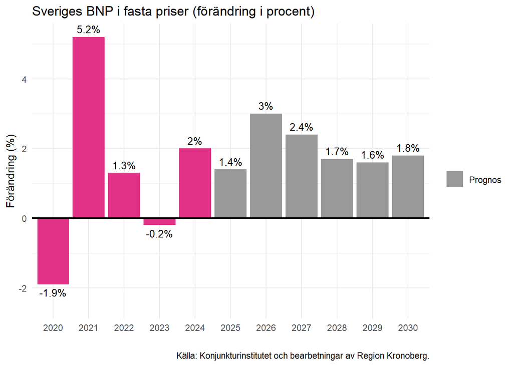

Barometerindikatorn ger en samlad bild av det svenska konjunkturläget genom att väga samman stämningsläget i näringslivet och bland hushållen. Ett värde på 100 motsvarar det historiska genomsnittet (normalläge). Värden över 100 indikerar generellt ett starkare stämningsläge än normalt, medan värden under 100 signalerar ett svagare stämningsläge. Värden över 110 signalerar högkonjunktur och värden under 90 indikerar lågkonjunktur.

I oktober 2026 uppgick barometerindikatorn till **108.1**, vilket indikerar **ett starkare stämningsläge än normalt**. Detta var en ökning med 0.9 enheter jämfört med föregående månad. Hushållens konfidensindikator föll kraftigt i oktober och stämningsläget är återigen något svagare än normalt. Framför allt har förväntningarna på den egna ekonomin och Sveriges ekonomi framöver försämrats. Hushållen är fortsatt försiktiga när det gäller kapitalvaruinköp, samtidigt som inflationsförväntningarna har stigit. I näringslivet var det sammantagna stämningsläget ett mycket starkt stämningsläge som tyder på högkonjunktur.

Tillverkningsindustrins konfidensindikator steg kraftigt i oktober och visar på ett betydligt starkare stämningsläge än normalt. Uppgången förklaras av mer optimistiska produktionsplaner, förbättrade bedömningar av orderstockarna och att färdigvarulagren i mindre utsträckning än normalt bedöms vara för stora. Orderingången har ökat mer än normalt på både hemma- och exportmarknaden under de senaste tre månaderna. Även företagens förväntningar på försäljningspriserna ligger tydligt över det normala och pekar på fortsatta prishöjningar. Antalet anställda uppges ha stigit något under de senaste tre månaderna. Anställningsplanerna har stärkts och pekar nu på en viss ökning av personalstyrkan på kort sikt.

Handeln uppvisar fortsatt ett mycket starkare stämningsläge än normalt, även om konfidensindikatorn sjönk något i oktober. Företagen rapporterar i betydligt större utstäckning än normalt att försäljningsvolymerna har ökat under de senaste tre månaderna, och förväntningarna på den kommande försäljningen är fortsatt positiva. Samtidigt är anställningsplanerna mer återhållsamma än normalt.

Byggsektorns stämningsläge var oförändrat i oktober och är något starkare än normalt. Det finns dock skillnader inom sektorn. Husbyggandet har ett svarare stämningsläge än normalt, medan anläggningsverksamhet och specialiserad bygg- och anläggning ligger över normalläget. Företagens förväntningar på byggandet de kommande tre månaderna är mer optimistiska än normalt, liksom anställningsplanerna. Samtidigt uppger drygt hälften av företagen att otillräcklig efterfrågan begränsar byggandet.

Tjänstesektorns konfidensindikator steg ytterligare i oktober och visar på ett starkare stämningsläge än normalt. Företagens syn på efterfrågan har förbättrats, både sett till de senaste tre månaderna och förväntningarna framåt. Anställningsplanerna pekar fortsatt på en normal ökning av personalstyrkan, samtidigt som företagens bedömning av den nuvarande uppdragsvolymen har förbättrats och nu ligger på en normal nivå.

[interactive chart not shown]

**Beskrivning av diagram:** Linjediagram som visar den övergripande Barometerindikatorn med delindex Konfidensindikator hushåll och Totala näringslivet.

# Arbetsmarknad

## Arbetslöshet

Arbetslösheten i Kronoberg uppgick till **6.6%** i september 2026. Jämfört med samma månad ifjol har arbetslösheten minskat med 0.5 procentenheter. Under de senaste sex månaderna visar trenden en minskning med 0.1 procentenheter. Den aktuella arbetslösheten är **normal** i förhållande till det historiska snittet sedan januari 2022<sup>1</sup>.

[interactive chart not shown]

**Beskrivning av diagram:** Linjediagram som visar arbetslösheten i Kronobergs län och i riket mellan 2022 och 2026. Kurvorna har följt liknande utveckling över tid och arbetslösheten i Kronoberg har legat över riksnittet. Dock ligger arbetslösheten i Kronoberg numera ungefär i nivå med rikssnittet.

## Långtidsarbetslöshet

I september 2026 var **4391 personer** långtidsarbetslösa, vilket motsvarar 66 procent av det totala antalet arbetslösa i Kronoberg. Med långtidsarbetslösa avses personer som har varit arbetslösa mer än sex månader. Under de senaste sex månaderna har antalet långtidsarbetslösa **minskat**. Jämfört med genomsnittet under Covid-19-pandemin 2020–2021 ligger antalet långtidsarbetslösa i den senaste mätningen på en mycket lägre nivå.

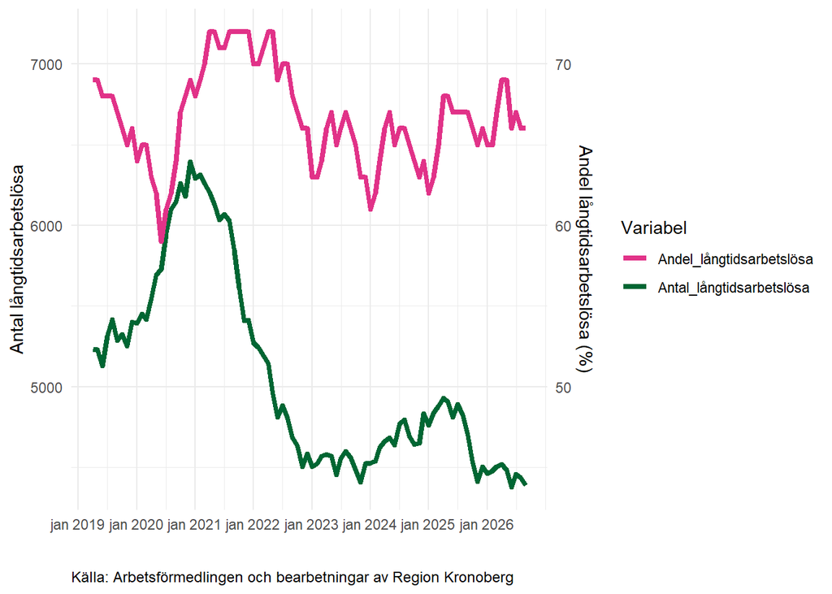

## Vakanser

Det totala antalet lediga jobb<sup>2</sup> på arbetsmarknaden i Kronobergs län uppgick till **1327 stycken** i september 2026. Det är en **minskning** i jämförelse med samma månad föregående år, och en ökning med 146 lediga jobb jämfört med föregående månad.

Statistiken speglar efterfrågan på arbetskraft i Kronobergs län och kan ge en indikation på konjunkturutvecklingen i länet. En ökning av antalet lediga jobb tyder ofta på en starkare konjunktur och ett ökat behov av arbetskraft. Motsatt gäller att en minskning av antalet lediga jobb signalerar att arbetsmarknaden bromsar in.

En hög arbetslöshet i kombination med många lediga jobb kan tyda på en matchningsproblematik - dvs. att arbetsgivarna har svårt att hitta kompetens som motsvarar kraven i de lediga tjänsterna, trots att det finns arbetssökande.

Diagrammet visar antalet lediga jobb över tid, med en uppdelning mellan sommarjobb och andra lediga jobb mellan år 2020 - 2026. Trenden har en tydlig säsongsvariation där antalet lediga jobb ökar markant under våren och sommaren, för att sedan sjunka under hösten. Sommarjobben bidrar till topparna under perioden. Åren 2020–2021 påverkades mycket av pandemin med färre lediga jobb, medan vi ser en återhämtning och stark ökning från och med 2022. Efter återhämtningen 2022–2023 har antalet lediga jobb visat tecken på en svagt nedåtgående trend.

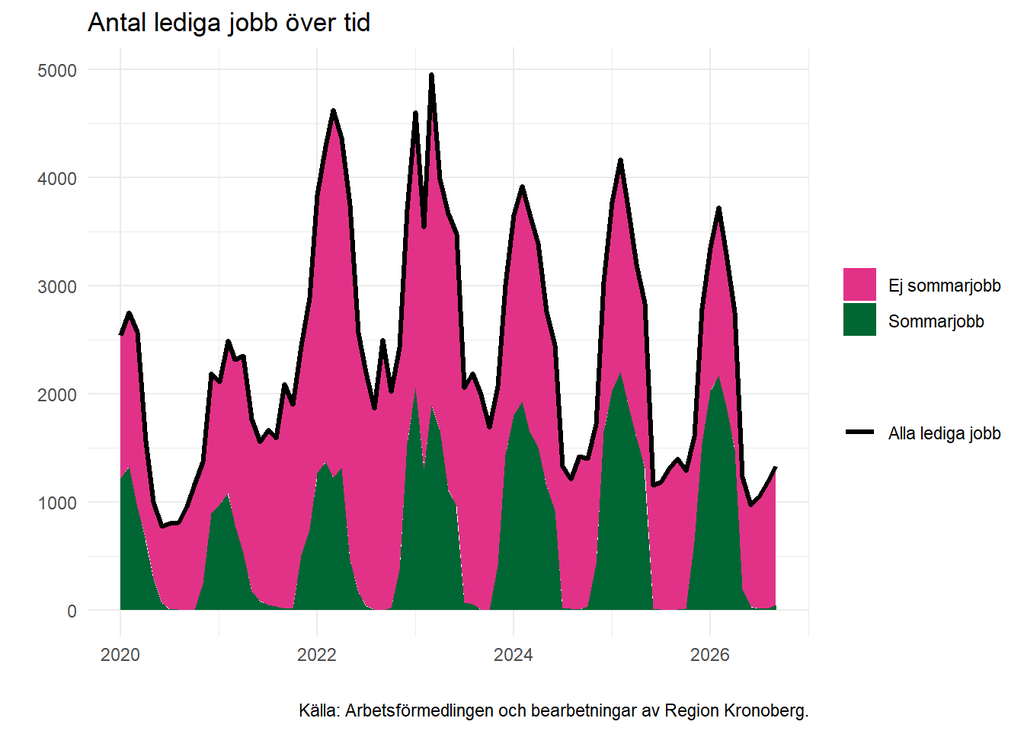

## Varsel

I september 2026 varslades **60 personer** i Kronobergs län, vilket var en **ökning** jämfört med föregående månad. Under helåret 2025 varslades totalt 631 personer i Kronobergs län, vilket är färre än de 976 som varslades under 2024.  
Under september 2026 ökade antalet varslade personer i de sydsvenska grannlänen Skåne och Halland. I länen Jönköping och Blekinge minskade antalet varslade personer i jämförelse med föregående månad. Antalet varslade personer var oförändrat i Kalmar län jämfört med föregående månad. Under det senaste kvartalet har antalet varslade personer i Kronoberg legat **på en relativt låg nivå** jämfört med genomsnittet för grannlänen.

[interactive chart not shown]

**Beskrivning av diagram:** Linjediagram som visar antalet varsel i Kronoberg och i de sydsvenska grannlänen Blekinge, Halland, Jönköping, Kalmar och Skåne.

# Företagande

## Konkurser

Antalet konkurser i Kronobergs län uppgick till **8 stycken** under september 2026. Det är en ökning med 1 konkurser jämfört med föregående månad. Totalt har **104 företag** gått i konkurs under perioden januari till och med september 2026. Under helåret 2025 gick 147 företag i konkurs, jämfört med 165 år 2024 och 143 år 2023. Antalet konkurser år 2025 var därmed lägre jämfört med 2024, men ungefär i nivå jämfört med 2023.

Jämfört med föregående månad ökade antalet konkurser i Jönköpings, Kalmar och Skåne län och antalet konkurser minskade i Blekinge och Hallands län.

[interactive chart not shown]

**Beskrivning av diagram:** Linjediagram som visar antalet konkurser i Kronoberg och i de sydsvenska grannlänen Blekinge, Halland, Jönköping, Kalmar och Skåne.

## Nystartade företag

Under september månad etablerades **112 nya företag** i Kronobergs län. Totalt har 736 nya företag startats under perioden januari till och med september 2026, vilket kan jämföras med 605 företag under samma period 2025. För helåret 2025 startades totalt 867 nya företag, jämfört med 794 företag 2024 och 941 företag 2023. Statistiken omfattar de fyra vanligaste bolagsformerna: aktiebolag, enskild näringsidkare<sup>3</sup>, handelsbolag och kommanditbolag.

[interactive chart not shown]

**Beskrivning av diagram:** Linjediagram som visar antalet nystartade företag per månad i Kronobergs län, med årsserier från 2020 och framåt. Antalet företag tenderar att minska under sommaren och öka igen mot hösten.

# Noter

1. Normal arbetslöshet i förhållande till snittet är definierad som att arbetslösheten faller inom +/- 0,5 procentenheter från genomsnittet sedan januari 2022. En arbetslöshet ovanför eller under detta intervall definieras som hög respektive låg.
2. Statistik om alla lediga jobb är ändrad från september 2024 och bakåt i tiden till januari 2004. Läs mer om varför på arbetsförmedlingens hemsida. Länk: [Rättad statistik om lediga jobb - Arbetsförmedlingen](https://arbetsformedlingen.se/om-oss/press/nyheter/nyhetsarkiv/2024-12-12-rattad-statistik-om-lediga-jobb)
3. Statistiken gällande enskilda näringsidkare omfattar bara de som finns i Bolagsverkets register. Många enskilda näringsidkare är endast registrerade hos Skatteverket och saknas därför i denna statistik.

# Om webbplatsen

**Tillgänglighetsredogörelse**

Region Kronoberg står bakom den här webbplatsen. Vi vill att så många som möjligt ska kunna använda webbplatsen. Det här dokumentet beskriver hur webbplatsen uppfyller lagen om tillgänglighet till digital offentlig service, eventuella kända tillgänglighetsproblem och hur du kan rapportera brister till oss så att vi kan åtgärda dem.

**Hur tillgänglig är webbplatsen?** Webbplatsen är förenlig med lagen om tillgänglighet till digital offentlig service.

**Vad kan du göra om du inte kan använda delar av webbplatsen?** Om du behöver innehåll från webbplatsen som inte är tillgängligt för dig, men som är undantaget från lagens tillämpningsområde enligt beskrivning nedan, kan du kontakta oss. Svarstiden är normalt tre arbetsdagar.

Du kan kontakta oss på följande sätt:  
- Skicka e-post till region@kronoberg.se  
- Ring 0470 - 58 80 00

**Rapportera brister i webbplatsens tillgänglighet.** Vi strävar hela tiden efter att förbättra webbplatsens tillgänglighet. Om du upptäcker problem som inte är beskrivna på den här sidan, eller om du anser att vi inte uppfyller lagens krav, kontakta oss så att vi får veta att problemet finns.

**Tillsyn.** Myndigheten för digital förvaltning har ansvaret för tillsyn för lagen om tillgänglighet till digital offentlig service. Om du inte är nöjd med hur vi hanterar ditt påpekande om bristande webbtillgänglighet eller din begäran om tillgängliggörande av innehåll kan du anmäla till [Myndigheten för digital förvaltning (DIGG)](https://www.digg.se/tdosanmalan).

**Teknisk information om webbplatsens tillgänglighet.** Den här webbplatsen är förenlig med nivå AA i standarden Web Content Accessibility Guidelines version 2.1.

*Innehåll som inte omfattas av lagen.* Användning utan synförmåga eller användning med nedsatt syn.

**Hur vi testat webbplatsen.** Region Kronoberg har uppskattat tillgängligheten utan granskning. Senaste bedömningen gjordes den 25 juni 2025. Webbplatsen publicerades den 25 juni 2025. Redogörelsen uppdaterades senast den 25 juni 2025.